# Chapter One: Practice Problem Solutions

Allison Theobold

2020-09-15

```r
## By specifying message = FALSE in the above code chunk, you do not get output when you load the tidyverse package
library(tidyverse)
```

## Exercise 1.1

```r
treadmill <- read_csv("https://raw.githubusercontent.com/atheobold/stat-313/master/book_data/treadmill.csv")
treadmill %>%
  summarize(mean_age = mean(Age),
            sd_age = sd(Age),
            mean_weight = mean(BodyWeight),
            sd_weight = sd(BodyWeight))
```

```
## # A tibble: 1 x 4
##   mean_age sd_age mean_weight sd_weight
##      <dbl>  <dbl>       <dbl>     <dbl>
## 1     47.7   5.21        77.4      8.33
```

It is common to report characteristics of participants in a study for a variety of reasons. First, it allows for readers to assess if the characteristics of the participants is **very different** from what you may expect in general (e.g. all participants are over 6 feet 8 inches tall). Second, it helps the reader think critically if they would expect that the relationship(s) being explored in the study should/could had different outcomes in different characteristics of participants (e.g. females metabolize alcohol slower than males). Third, this description allows for the reader to determine how applicable the study’s findings are to other groups of individuals. For example, if this study was for individuals 25 years younger, you would likely have some issues inferring the results onto individuals who were in their 50s.

## Exercise 1.2

Previously, in the distribution of run times we saw that most participants had times around 11 minutes to complete the 1.5 miles, a 7.3 minute mile pace. The worst runner covered 1.5 miles in 14 minutes, a 9.3 minute mile, and the best runner covered the distance at a 5.4 minute mile pace. Based on the fast paces of the runners, I would have expected that they could have been competitive runners. Additionally, from these fast paces, many people could have expected that the runners would be younger. The summaries of ages tells us that, in fact, these runners are a bit older, with an average age of around 47 years.

At first glance, the summaries of the body weight of the runners is quite alarming! A mean weight of 77.4 seems like an **incredibly** small person. However, it should indicate to us that the variable was likely recorded in a unit different from pounds.

## Exercise 1.3

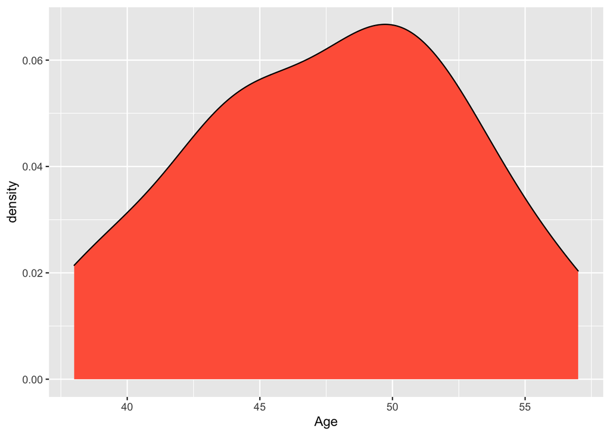

```r
## You can pipe the data into the ggplot() function!
treadmill %>%
  ggplot(aes(x = Age)) +
  geom_density(fill = "tomato")
```

The distribution of ages is fairly symmetric, except for one small bump near 45 years old. There could be concerns that this could be a second mode/peak in the distribution, but it looks fairly small, so I wouldn’t be too concerned.

The distribution is not skewed to the left or right, and instead has very short tails! The youngest runner was about 38 and the oldest runner was about 57.

## Exercise 1.4

```r
treadmill <- treadmill %>%
  mutate(BodyWeight_lb = 2.205 * BodyWeight)

treadmill %>%
  summarize(mean_weight = mean(BodyWeight_lb),
            sd_weight = sd(BodyWeight_lb))
```

```
## # A tibble: 1 x 2
##   mean_weight sd_weight
##         <dbl>     <dbl>
## 1        171.      18.4
```

## Exercise 1.5

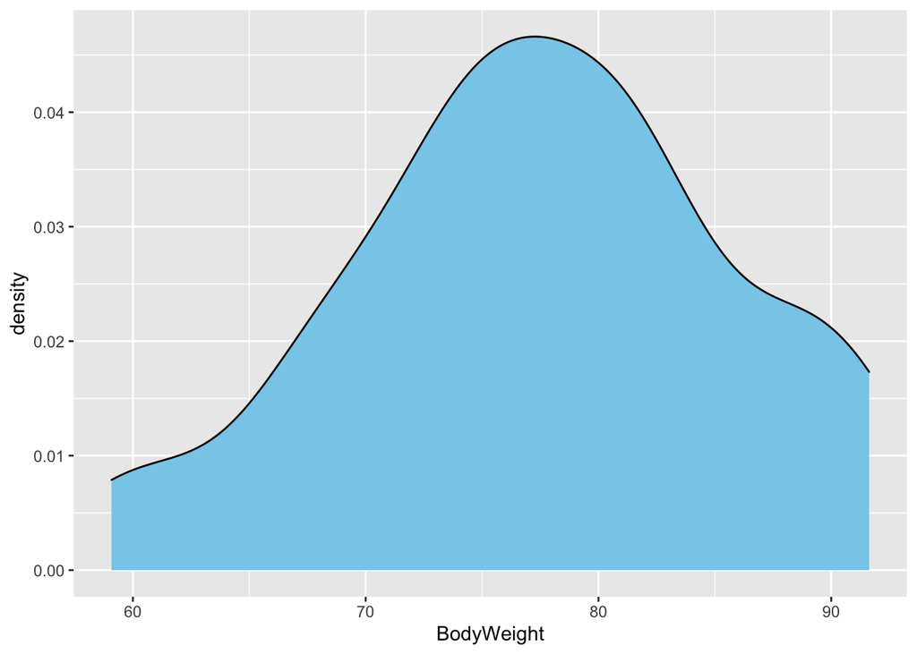

```r
treadmill %>%
  ggplot(aes(x = BodyWeight)) +
  geom_density(fill = "sky blue")
```

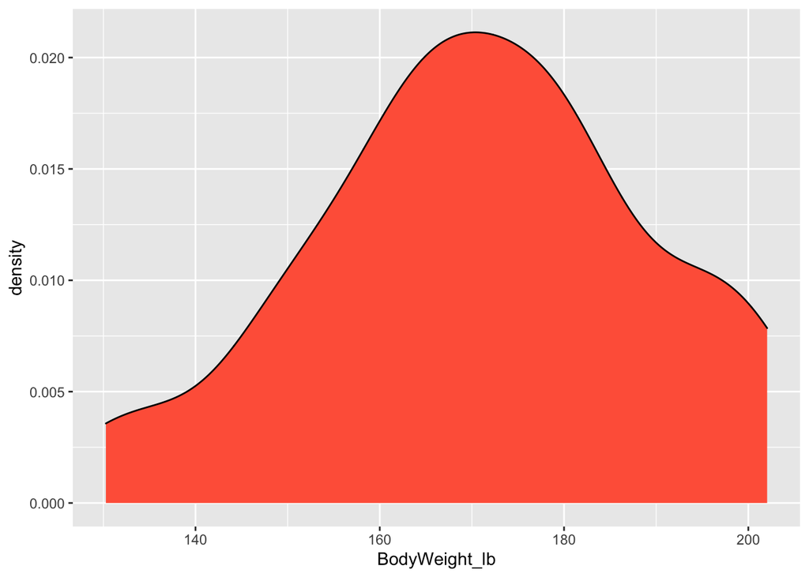

```r
treadmill %>%
  ggplot(aes(x = BodyWeight_lb)) +
  geom_density(fill = "tomato")
```

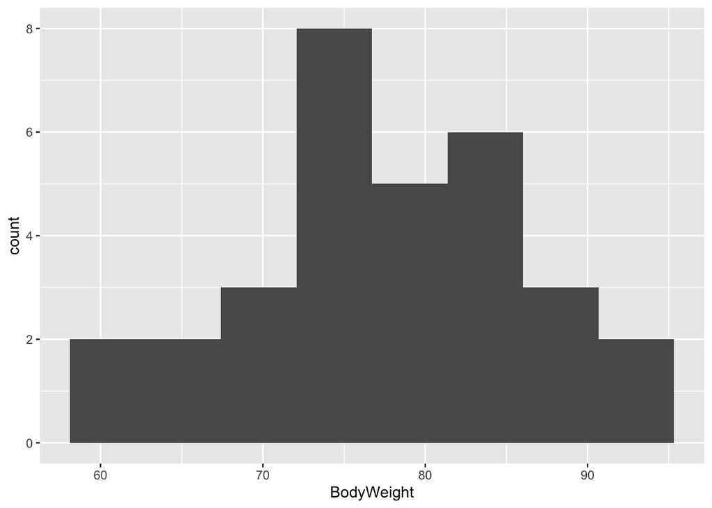

```r
treadmill %>%
  ggplot(aes(x = BodyWeight)) +
  geom_histogram(bins = 8)
```

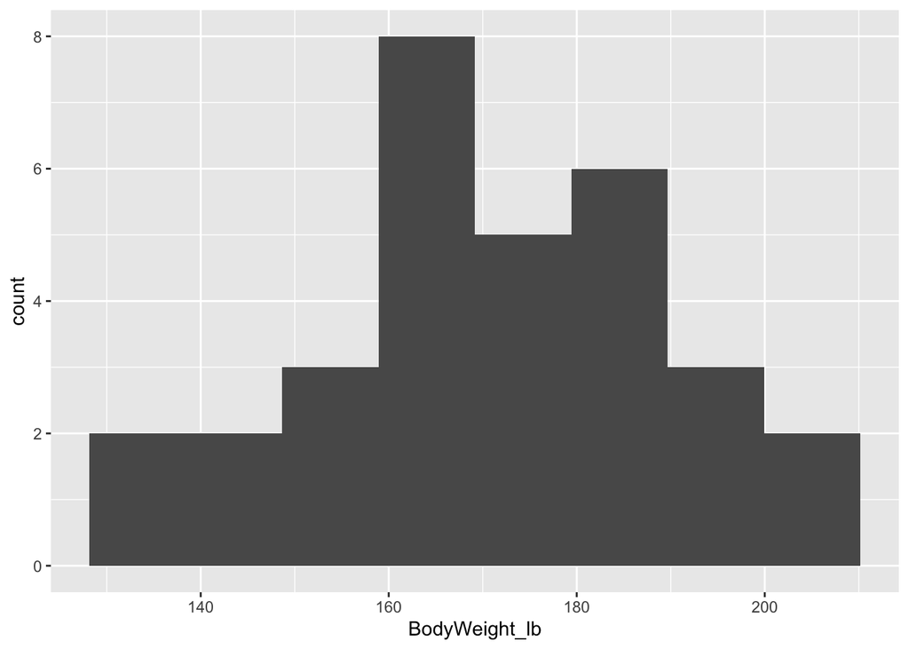

```r
 treadmill %>%
  ggplot(aes(x = BodyWeight_lb)) +
  geom_histogram(bins = 8)
```

The distribution of the body weights is the same for pounds and kilograms. This tells us that changing the units of a variable **does not** change its distribution.

**Additional Data Visualization Exploration**

If you are interested in arranging multiple plots on the page, you can use the `grid.arrange()` function in the gridExtra package to arrange plots into multiple columns and rows. To do this you use the following steps:

1. Create the plot and assign it to an object
2. Use the `grid.arrange()` function to arrange the plot objects how you would like them to appear on the page. The number of rows is specified with the `nrow` argument, and the number of columns is specified with the `ncol` argument.

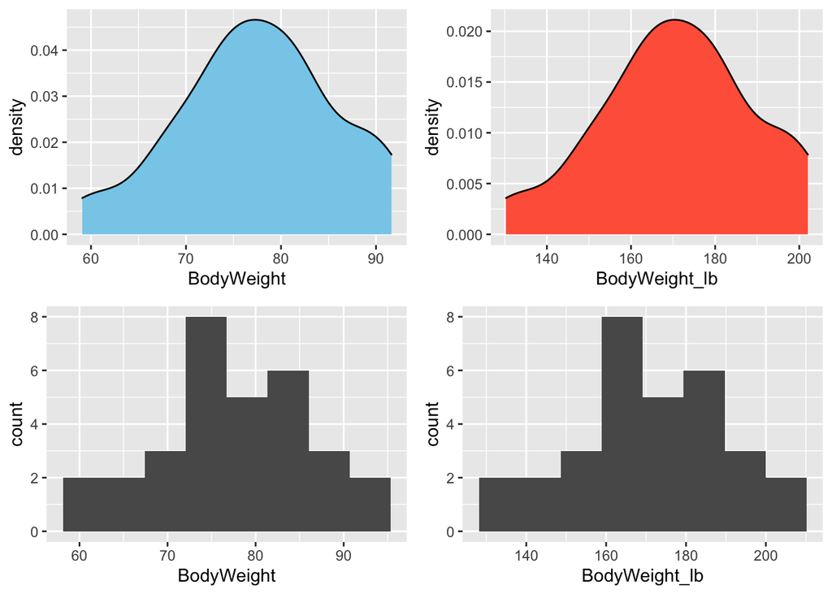

```r
## You will need to install the gridExtra package in order for you to be able to load it!
library(gridExtra)

plot1 <- treadmill %>%
  ggplot(aes(x = BodyWeight)) +
  geom_density(fill = "sky blue")

plot2 <- treadmill %>%
  ggplot(aes(x = BodyWeight_lb)) +
  geom_density(fill = "tomato")

plot3 <- treadmill %>%
  ggplot(aes(x = BodyWeight)) +
  geom_histogram(bins = 8)

 plot4 <- treadmill %>%
  ggplot(aes(x = BodyWeight_lb)) +
  geom_histogram(bins = 8)

grid.arrange(plot1, plot2, plot3, plot4, nrow = 2, ncol = 2)
```